# Day Care Fines

```r
library(mosaic)
library(plotly)
library(DT)
library(pander)
library(car)
library(tidyverse)

# To get the "late" dataset into your R Console,
# you need to go to your file menu of R-Studio and select
# "Session, Set working directory, To source file location"
# Then click the green "play" arrow in
# the top right corner of this gray R-Chunk.

## Wide data from original article:
late <- read.csv("../../Data/late.csv", header=TRUE)

## Change to "long" data for use in R:
Late <- pivot_longer(late, #Start with wide data set late
               cols = starts_with("Week"), #Find columns to gather from long data
               names_to = "Week", #New column name of Weeks in long data
               names_prefix = "Week", #Remove prefix of Week from Week1, Week2, ...
               names_transform = list(Week= ~as.numeric(.x)), #Make Week a numeric column of data
               values_to = "NumberofLateChildren") #Name of data column in long data
```

**Comments to Critiquers:**

## Background

### Overview

There are 10 private day-care centers in Haifa, Israel for children ages 1-4. There are some parents who pick up their children later from these day-care centers. Teachers in these day-care facilities deal with parents coming to pick up their children late. The point of this study is to see if fining parents who come pick up their children late decreases the amount of times parents come late to pick up their child or children. To do this data for day-care centers had to be divided into three sections: the pre-fine period, fine period, and the post fine period. This whole study is done with 20 weeks worth of data. The pre-fine period is the first 0-4 weeks, the fine period is weeks 5-16, and the post-fine period is weeks 17-20.

### Study Details

This background is quoted directly from the article [“A Fine is a Price”](http://rady.ucsd.edu/faculty/directory/gneezy/pub/docs/fine.pdf).

There are two types of day-care centers in Israel: private and public. A study was conducted in 10 private day-care centers in the city of Haifa from January to June 1998. All of these centers are located in the same part of town, and there is no important difference among them. During the day children are organized into groups according to age, from 1 to 4 years old. Each day-care center is allowed to hold a maximum of 35 children. In some exceptional cases a few additional children are allowed. The fee for each child is NIS 1,400 per month. (The NIS is the New Israeli Shekel.) At the time of the study, a U.S. dollar was worth approximately NIS 3.68, so the fee was about $380 at that time.

The contract signed at the beginning of the year states that the day-care center operates between 0730 and 1600. There is no mention of what happens if parents come late to pick up their children. In particular, before the beginning of the study, there was no fine for coming late. When parents did not come on time, one of the teachers had to wait with the children concerned. Teachers would rotate in this task, which is considered part of the job of a teacher, a fact that is clearly explained when a teacher is hired. Parents rarely came after 1630.

A natural option [to fix the problem of parents showing up late] is to introduce a fine: every time a parent comes late, [they] will have to pay a fine. Will that reduce the number of parents who come late? If the fine is removed, will things revert back to the way they were originally?

The overall period of the study was 20 weeks. In the first 4 weeks we simply recorded the number of parents who arrived late each week. At the beginning of the fifth week, we introduced a fine in six of the 10 day-care centers, which had been selected randomly. The announcement of the fine was made with a note posted on the bulletin board of the day-care center. Parents tend to look at this board every day, since important announcements are posted there. The announcement specified that the fine would be NIS 10 for a delay of 10 minutes or more. The fine was per child; thus, if parents had two children in the center and they came late, they had to pay NIS 20. Payment was made to the principal of the day-care center at the end of the month. Since monthly payments are made to the owner during the year, the fines were added to those amounts. The money was paid to the owner, rather then to the teacher who was staying late (and did not get any additional money). The teachers were informed of the fine but not of the study. Registering the names of parents who came late was a common practice in any case.

At the beginning of the seventeenth week, the fine was removed with no explanation. Notice of the cancellation was posted on the board. If parents asked why the fines were removed, the principals were instructed to reply that the fine had been a trial for a limited time and that the results of this trial were now being evaluated.

A comparison with other fines in Israel may give an idea of the size of the penalty that was introduced. A fine of NIS 10 is relatively small but not insignificant. In comparison, the fine for illegal parking is NIS 75; the fine for driving through a red light is NIS 1,000 plus penalties; the fine for not collecting the droppings of a dog is NIS 360. For many of these violations, however, detection and enforcement are low or, as in the case of dog dirt, nonexistent in practice. A baby-sitter earns between NIS 15 and NIS 20 per hour. The average gross salary per month in Israel at the time of the study was NIS 5,595.

### The Data (Wide)

The `late` Day Care Center data is shown here in the “wide data format”.

```r
#Show the full width of the "Wide" version of the late data:
pander(late, split.tables = Inf)
```

| Treatment | Center | No.ofChildren | Week1 | Week2 | Week3 | Week4 | Week5 | Week6 | Week7 | Week8 | Week9 | Week10 | Week11 | Week12 | Week13 | Week14 | Week15 | Week16 | Week17 | Week18 | Week19 | Week20 |
| --- | --- | --- | --- | --- | --- | --- | --- | --- | --- | --- | --- | --- | --- | --- | --- | --- | --- | --- | --- | --- | --- | --- |
| Fine | 1 | 37 | 8 | 8 | 7 | 6 | 8 | 9 | 9 | 12 | 13 | 13 | 15 | 13 | 14 | 16 | 14 | 15 | 16 | 13 | 15 | 17 |
| Fine | 2 | 35 | 6 | 7 | 3 | 5 | 2 | 11 | 14 | 9 | 16 | 12 | 10 | 14 | 14 | 16 | 12 | 17 | 14 | 10 | 14 | 15 |
| Fine | 3 | 35 | 8 | 9 | 8 | 9 | 3 | 5 | 15 | 18 | 16 | 14 | 20 | 18 | 25 | 22 | 27 | 19 | 20 | 23 | 23 | 22 |
| Fine | 4 | 34 | 10 | 3 | 14 | 9 | 6 | 24 | 8 | 22 | 22 | 19 | 25 | 18 | 23 | 22 | 24 | 17 | 15 | 23 | 25 | 18 |
| Fine | 5 | 33 | 13 | 12 | 9 | 13 | 15 | 10 | 27 | 28 | 35 | 10 | 24 | 32 | 29 | 29 | 26 | 31 | 26 | 35 | 29 | 28 |
| Fine | 6 | 28 | 5 | 8 | 7 | 5 | 5 | 9 | 12 | 14 | 19 | 17 | 14 | 13 | 10 | 15 | 14 | 16 | 6 | 12 | 17 | 13 |
| Control | 7 | 35 | 7 | 10 | 12 | 6 | 4 | 13 | 7 | 8 | 5 | 12 | 3 | 5 | 6 | 13 | 7 | 4 | 7 | 10 | 4 | 6 |
| Control | 8 | 34 | 12 | 9 | 14 | 18 | 10 | 11 | 6 | 15 | 14 | 13 | 7 | 12 | 9 | 9 | 17 | 8 | 5 | 11 | 8 | 13 |
| Control | 9 | 34 | 3 | 4 | 9 | 3 | 3 | 5 | 9 | 5 | 2 | 7 | 6 | 6 | 9 | 4 | 9 | 2 | 3 | 8 | 3 | 5 |
| Control | 10 | 32 | 15 | 13 | 13 | 12 | 10 | 9 | 15 | 15 | 15 | 10 | 17 | 12 | 13 | 11 | 14 | 17 | 12 | 9 | 15 | 13 |

### The Data (Long)

The `Late` Day Care Center data is shown here in the “long data format”.

```r
pander(Late)
```

| Treatment | Center | No.ofChildren | Week | NumberofLateChildren |
| --- | --- | --- | --- | --- |
| Fine | 1 | 37 | 1 | 8 |
| Fine | 1 | 37 | 2 | 8 |
| Fine | 1 | 37 | 3 | 7 |
| Fine | 1 | 37 | 4 | 6 |
| Fine | 1 | 37 | 5 | 8 |
| Fine | 1 | 37 | 6 | 9 |
| Fine | 1 | 37 | 7 | 9 |
| Fine | 1 | 37 | 8 | 12 |
| Fine | 1 | 37 | 9 | 13 |
| Fine | 1 | 37 | 10 | 13 |
| Fine | 1 | 37 | 11 | 15 |
| Fine | 1 | 37 | 12 | 13 |
| Fine | 1 | 37 | 13 | 14 |
| Fine | 1 | 37 | 14 | 16 |
| Fine | 1 | 37 | 15 | 14 |
| Fine | 1 | 37 | 16 | 15 |
| Fine | 1 | 37 | 17 | 16 |
| Fine | 1 | 37 | 18 | 13 |
| Fine | 1 | 37 | 19 | 15 |
| Fine | 1 | 37 | 20 | 17 |
| Fine | 2 | 35 | 1 | 6 |
| Fine | 2 | 35 | 2 | 7 |
| Fine | 2 | 35 | 3 | 3 |
| Fine | 2 | 35 | 4 | 5 |
| Fine | 2 | 35 | 5 | 2 |
| Fine | 2 | 35 | 6 | 11 |
| Fine | 2 | 35 | 7 | 14 |
| Fine | 2 | 35 | 8 | 9 |
| Fine | 2 | 35 | 9 | 16 |
| Fine | 2 | 35 | 10 | 12 |

[output cut: 170 more lines]

## Introduction

As previously stated, the point of this study is to see if fining parents who come pick up their child/children late decreases the amount of times parents come late to pick up their child/children. The test that I will need to perform is a 2-Way ANOVA test.

### Hypothesis

1. Does issuing a fine affect the average number of children picked up late?

Factor: “Period”

Levels: “Pre-fine Weeks”, “Fine Weeks”, “Post-Fine Weeks”

H0: The average number of children picked up late for the Pre-fine, Fine, and Post-fine Weeks is equal (H0:μL=μM=μH=μ).

2. Does the treatment (control or fine group) affect the average number of children picked up late?

Factor: “Treatment”

Levels: “Control”, “Fine”

H0: The average number of children picked up late is the same for each treatment group (H0:μC=μF).

Ha: The average number of children picked up late is not the same for each treatment group (Ha:μC≠μF).

3. Does the effect of the period change for different types of treatment? (Does the effect of treatment change for the different periods?) In other words, is there an interaction between period and treatment?

H0:The effect of the period is the same for the types of treatment.

Ha:The effect of the period is not the same for the types of treatment.

## Data Analysis

```r
Late$Period <- cut(Late$Week, c(0,4,16,20), labels=c('Pre-fine Weeks','Fine Weeks','Post-Fine Weeks'), ordered_result=TRUE)

Late1 <- filter(Late, !is.na(Treatment))

Late1 <- filter(Late1, !is.na(Period))

aovOut <- aov(NumberofLateChildren ~ Period + Treatment + Period:Treatment, data=Late1)

summary(aovOut) %>% pander()
```

Analysis of Variance Model

|  | Df | Sum Sq | Mean Sq | F value | Pr(>F) |
| --- | --- | --- | --- | --- | --- |
| **Period** | 2 | 828 | 414 | 12.91 | 5.456e-06 |
| **Treatment** | 1 | 1740 | 1740 | 54.25 | 4.925e-12 |
| **Period:Treatment** | 2 | 847.7 | 423.9 | 13.22 | 4.162e-06 |
| **Residuals** | 194 | 6222 | 32.07 | NA | NA |

```r
#explain my results for all hypothesis
```

As we can see, the ANOVA test shows that there is a difference between at least one of the period’s average number of children late (we would reject the null) . It also shows there is a difference between at least between one of the multiple treatment groups (we would reject the null). Finally, the data analysis shows there is at least one significant difference between the interaction of the period and treatment factors in the number of children that are picked up late. However, before we can make any conclusions, we have to see if we even have a normal distribution and variance to make conclusions based off of the ANOVA test.

## Diagnostic Plots

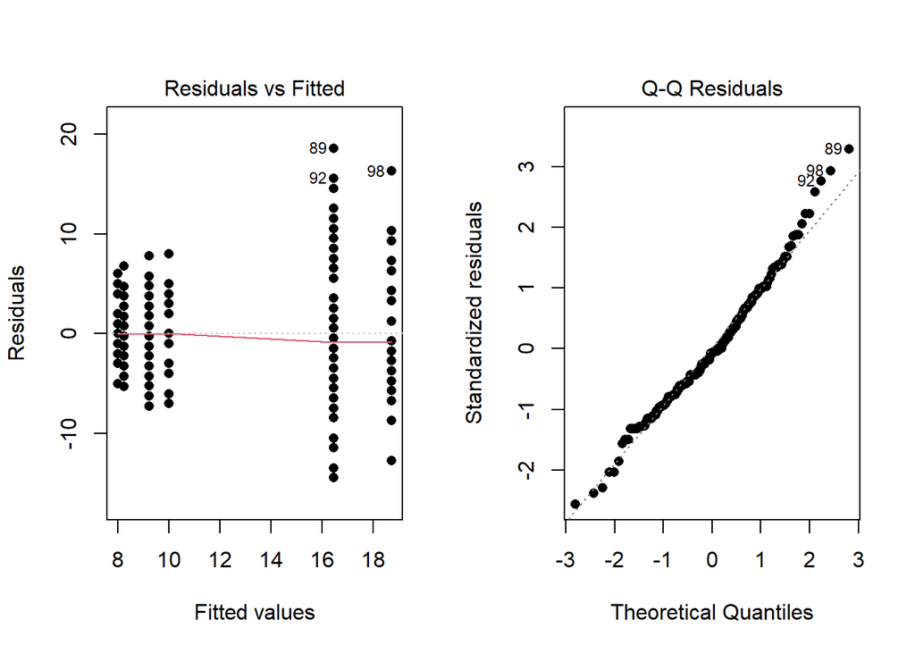

```r
par(mfrow = c(1,2))

plot(aovOut, which=1:2, pch=16)
```

The data of the residuals in the far right is about twice as long or more than the data of the residuals in the far left. Because of this, the variance is questionable. If you look at the QQPlot, it shows that the normality of the error terms is satisfied.Therefore, only the variance is questionable. However, we can still proceed with our tests.

## Graphical/Numerical Summary (Hypothesis 1)

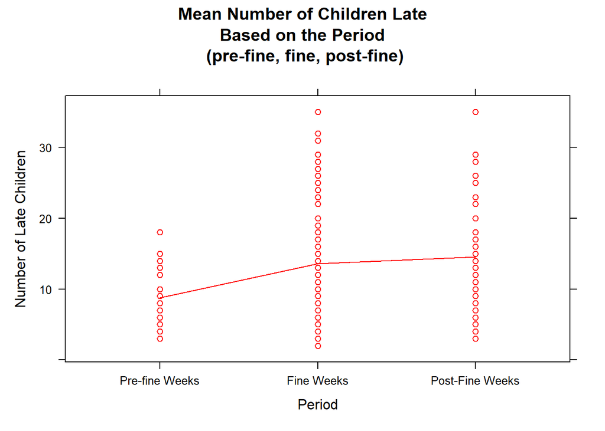

```r
xyplot(NumberofLateChildren ~ Period, data=Late1, type=c("p","a"), ylab= 'Number of Late Children', main=' Mean Number of Children Late \n Based on the Period \n (pre-fine, fine, post-fine)', col='red')
```

```r
Late1 %>%
  group_by(Period) %>%
  summarise(mean=mean(NumberofLateChildren),n=n()) %>%
  pander(caption='Mean Number of Children Late \n Based on the Period \n (pre-fine, fine, post-fine)')
```

Mean Number of Children Late Based on the Period (pre-fine, fine, post-fine)

| Period | mean | n |
| --- | --- | --- |
| Pre-fine Weeks | 8.8 | 40 |
| Fine Weeks | 13.56 | 120 |
| Post-Fine Weeks | 14.53 | 40 |

The graphical summary shows us that there is a difference between the average number of children late in the pre-fine weeks compared to the fine and post-fine weeks. There was on average less number of children picked up late in the pre-fine weeks compared to the fine and post-fine weeks. The post-fine weeks have a slightly higher average number of children picked up late compared to the fine weeks. This is, however, a slight difference.

If we look at the numerical summary, we can see that the pre-fine weeks had an average of 8.8 children being picked up late. Where as for the fine weeks it was 13.56 and slightly higher for the post-fine weeks at 14.53.

## Graphical/Numerical Summary (Hypothesis 2)

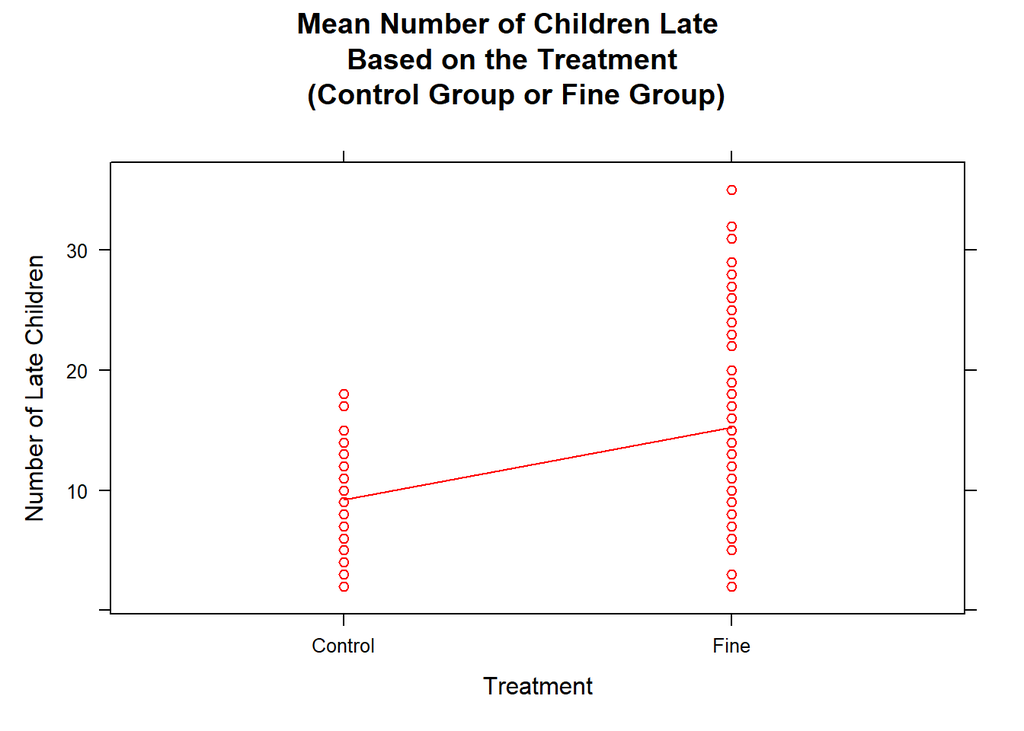

```r
xyplot(NumberofLateChildren ~ as.factor(Treatment), data=Late1, xlab='Treatment', type=c("p","a"), ylab= 'Number of Late Children', main='Mean Number of Children Late \n Based on the Treatment \n (Control Group or Fine Group)', col='red')
```

```r
Late1 %>%
  group_by(Treatment) %>%
  summarise(mean=mean(NumberofLateChildren),n=n()) %>%
  pander(caption='Mean Number of Children Picked Up Late Based on the Treatment (Control Group or Fine Group)')
```

Mean Number of Children Picked Up Late Based on the Treatment (Control Group or Fine Group)

| Treatment | mean | n |
| --- | --- | --- |
| Control | 9.188 | 80 |
| Fine | 15.21 | 120 |

In the graphical summary we can see that there is a great difference between the control and fine group in the number of children picked up late. The control group has ironically less number of children picked up late than the fine group. In the numerical summary we can see that the fine group has an average of 15.21 children picked up late whereas the control group has an average of 9.188 children picked up late.

## Graphical/Numerical Summary (Hypothesis 3)

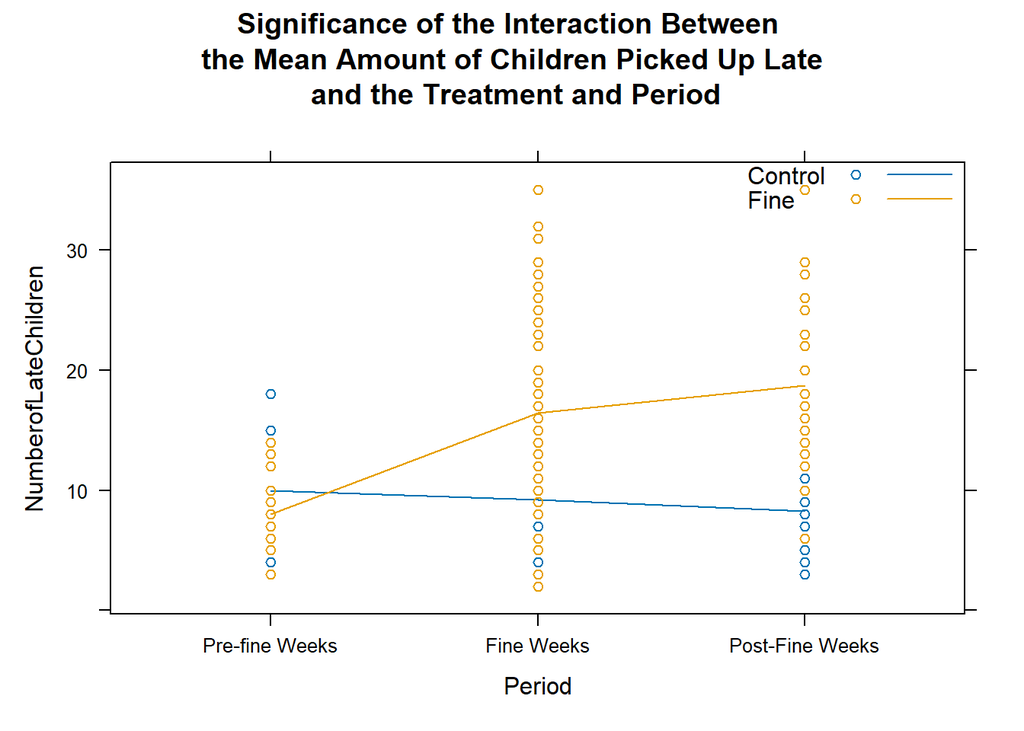

```r
xyplot(NumberofLateChildren ~ Period, data=Late, groups=Treatment, type=c("p","a"),
       main="Significance of the Interaction Between \n the Mean Amount of Children Picked Up Late \n and the Treatment and Period", auto.key=list(corner=c(1,1)))
```

```r
Late1 %>%
  group_by(Period, Treatment) %>%
  summarise(ave=mean(NumberofLateChildren), .groups='keep') %>%
  spread(Period, ave) %>%
  pander(caption='Mean # of Children Picked Up Late According to Treatment (Control,Fine) and Period Level (Pre-fine, fine, post-fine)')
```

Mean # of Children Picked Up Late According to Treatment (Control,Fine) and Period Level (Pre-fine, fine, post-fine)

| Treatment | Pre-fine Weeks | Fine Weeks | Post-Fine Weeks |
| --- | --- | --- | --- |
| Control | 10 | 9.229 | 8.25 |
| Fine | 8 | 16.44 | 18.71 |

The graphical summary for the third hypothesis shows us that the control group started to go slightly down in the average amount of children picked up late from the pre-fine weeks to the post-fine weeks. We can also see the fine group had more children being picked up late from the pre-fine weeks to the post-fine weeks. This is a large difference. Ironically, those within the fine group over time from the pre-fine weeks all the way to the post-fine weeks had a greater amount of children being picked up late. The control group stayed relatively the same in the average amount of children picked up late from the pre-fine weeks to the post-fine weeks.

In the numerical summary, we can see that the control group goes from an average of 10 children being picked up late in the pre-fine weeks to an average of 8.25 children being picked up late in the post-fine weeks. This is not much of a difference. However, for the fine group there is a large difference on the average number of children being picked up late from the pre-fine weeks to the post-fine weeks. It goes from an average of 8 to 18.71. This is a 10.71 average increase for the number of children being picked up late.

## Interpretation/Conclusion

We can conclude that giving fines to parents who pick up their children late doesn’t decrease the average amount of children being picked up late from the day-care centers. If anything, it increases it. Therefore, no fines should be given. If no fines are given, there will be less teachers that will have to stay after work hours to wait for the parent(s) to come pick up the child/children.